# cgMLST attribution experiments

10 December 2019

## Data and problem

- Core genome MLST data from ~650 human cases of campylobacteriosis from NZ in 2018-2019.
- cgMLST for ~200 isolates each from three potential reservoir food or environmental sources, collected concurrently.
- Problem: Attribute the human cases of campylobacteriosis to their most likely source.
- We know we can do this using just MLST. What happens if we have (lots) more genes?
- How should we choose the genes to use?

## Choosing the best genes

Use the F-statistic: \[ \begin{aligned} F &= \frac{\mathsf{Between~source~variation}}{\mathsf{Within~source~variation}}\\ &= \frac{\mathsf{Total~source~variation} - \mathsf{Within~source~variation}}{\mathsf{Within~source~variation}} \end{aligned} \] We can estimate Total and Within source variation just as the sum of squared pairwise distances.

Similar to how MANOVA or PERMANOVA works.

## Choosing the best genes

- Choose the gene that has maximal F.
- Choose the next gene that, combined with the first, maximises F.
- Keep adding the next best gene that maximises F combined with the genes already chosen.
- Locally optimal, not necessarily globally optimal.

## cgMLST attribution

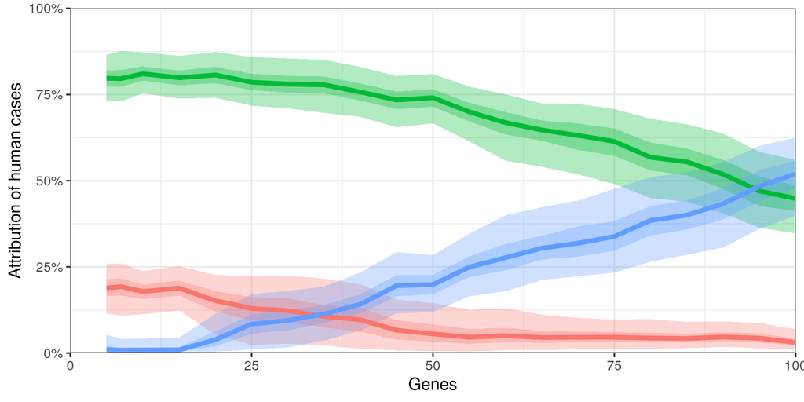

## What about MLST, Thépault et al, rMLST

- MLST: Standard 7 genes
- Thépault et al: 13 genes selected via GWAS to separate sources in the UK.
  - Thépault et al (2017) Genome-wide identification of host-segregating epidemiological markers for source attribution in *Campylobacter jejuni*.
- rMLST: Ribosomal MLST.

## MLST, Thépault et al, rMLST

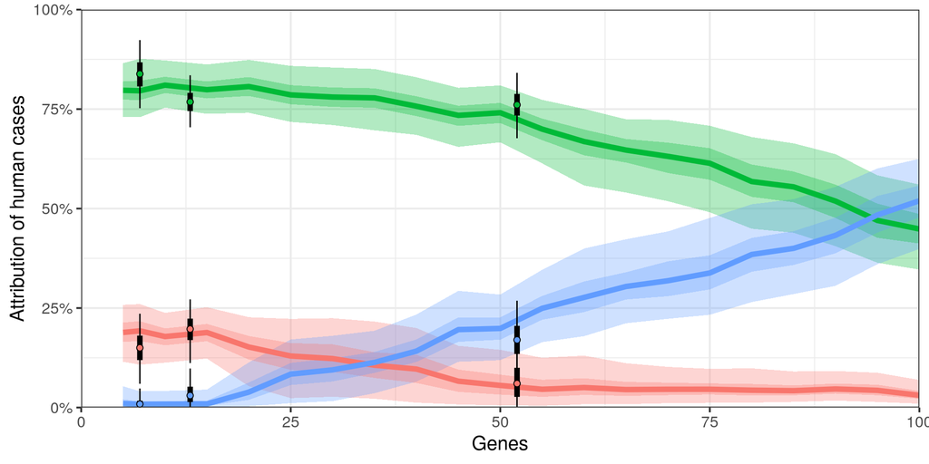

## Cross validation

- Use only the source isolates
- Divide into 10 groups, preserving source structure in each group.
- Use 9 to train the island model, and retain the last group as “Human” cases.
- Compare attributed source to actual source.
- Repeat across the 10 groups (cross-validation).

## Cross validation results

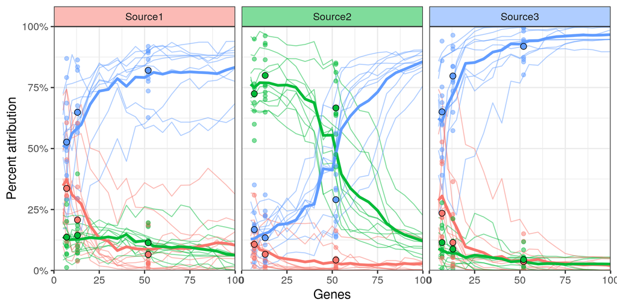

## What about 7 genes picked at random?

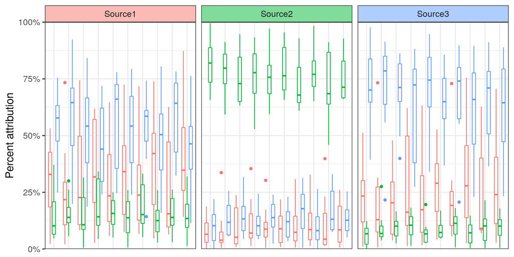

## Attribution from 7 random genes

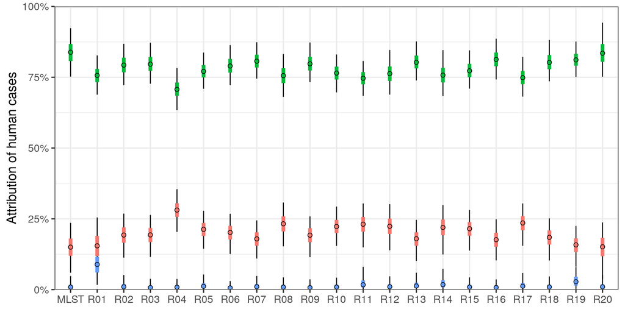

## Fixing the island model

- The problem is that increasing the number of genes messes up due to the leave one out likelihood.
- What happens is the diversity of the source has a very large impact on the mutation and recombination probabilities, and they are markedly different across sources.
- As the probability of seeing something different is these probabilities to the power of the number of genes, this favours the source with the least diversity.
- Instead, let’s fix the mutation and recombination probabilities across the sources to be the same.

## Cross validation

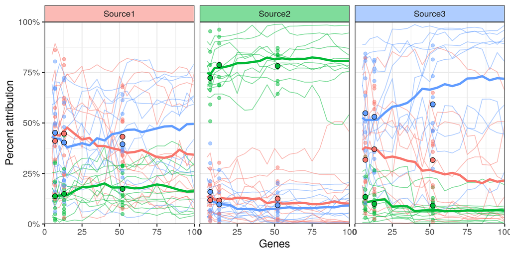

## Attribution

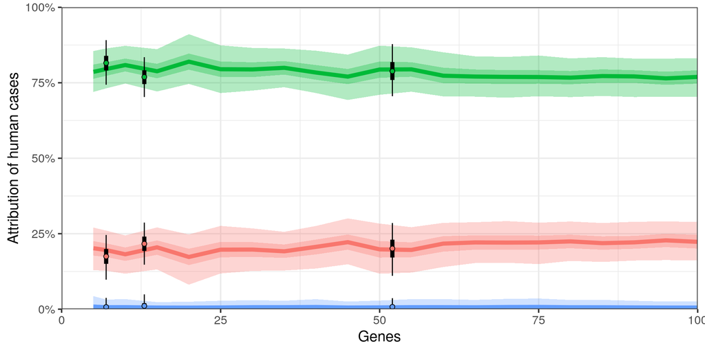

## Attribution from 7 random genes

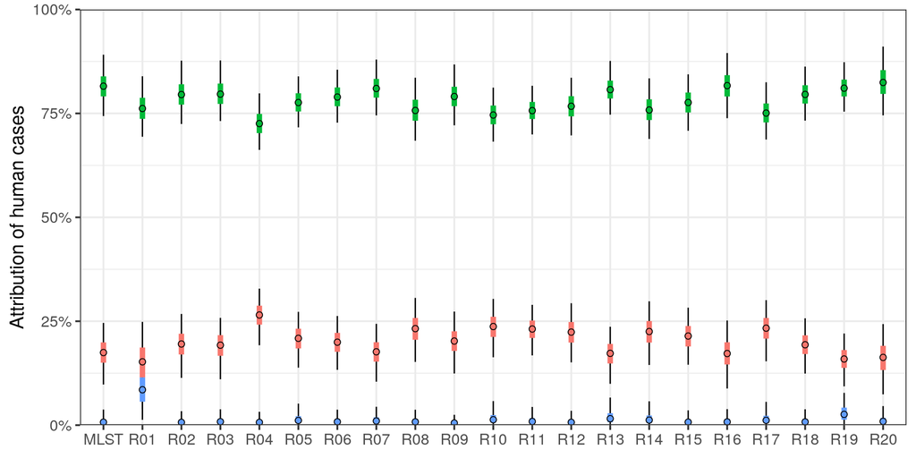

## Conclusion

- Increasing the number of genes means mutation and recombination probabilities need to be estimated in common across the sources.
- When done, choosing the “best” 5 or the “best” 100 genes doesn’t seem to make any difference in attribution.
- If using 7 genes, pretty much any 7 genes seem to do just as well as MLST.
- The F-statistic doesn’t appear to correspond well with how well attribution happens.
- Need a better measure!